# 343.02 Class Markdown: Data Wrangling

Oropendola

2024-09-03

## Mission overview

We want to compare temperature increases (or decreases) across time. To do this we must:

1. Extract a **baseline** period early in our dataset from “before” climate change likely accelerated.
2. Establish **norms**: average temperature values for units of time within that baseline (months or weeks).
3. Subtract the *norms* from the *observed temps* to calculate **anomalies**: the degrees a day was above or below a historic average.
4. Plot these anomalies to look for **trends**, determining the best format to visualize these trends, considering:
   - Plot type (point, box, column) & reinforcing aesthetics (color/fill).
   - Whether to view as individual day observations or summarize by months or years.

For a more in-depth explanation of anomalies, check out [this NOAA reference](https://www.ncei.noaa.gov/access/monitoring/dyk/anomalies-vs-temperature).

But before we can get to that, we need to setup our RMarkdown with packages & data.

## 0: Setup

To keep things *tidy* we like to begin our Markdown loading in all of the packages we’ll need. Because it comes with a number of `messages` about the packages in `tidyverse` and `warnings` about conflicts, I’ve **suppressed them** at the start of the R chunk.

```r
# require in our packages
require(lubridate)
require(tidyverse)
```

Then, we will want to read in and explore our data.

```r
# read in the data
rva <- read.csv("climate_data.csv",
                stringsAsFactors = T)
# What are the variable names & data types?
summary(rva)
```

```
##         STATION                                         NAME
##  USW00013740:30895   RICHMOND INTERNATIONAL AIRPORT, VA US:30895
##
##
##
##
##
##
##          DATE            PRCP            TMAX             TMIN
##  1939-03-01:    1   Min.   :0.000   Min.   : 12.00   Min.   :-12.00
##  1939-03-02:    1   1st Qu.:0.000   1st Qu.: 56.00   1st Qu.: 34.00
##  1939-03-03:    1   Median :0.000   Median : 72.00   Median : 48.00
##  1939-03-04:    1   Mean   :0.121   Mean   : 69.46   Mean   : 47.85
##  1939-03-05:    1   3rd Qu.:0.040   3rd Qu.: 84.00   3rd Qu.: 63.00
##  1939-03-06:    1   Max.   :8.790   Max.   :105.00   Max.   : 81.00
##  (Other)   :30889   NA's   :1216    NA's   :1216     NA's   :1216
```

```r
str(rva) #str shows what is a factor, date should NOT be a factor. Use the lubricate package to change this
```

```
## 'data.frame':    30895 obs. of  6 variables:
##  $ STATION: Factor w/ 1 level "USW00013740": 1 1 1 1 1 1 1 1 1 1 ...
##  $ NAME   : Factor w/ 1 level "RICHMOND INTERNATIONAL AIRPORT, VA US": 1 1 1 1 1 1 1 1 1 1 ...
##  $ DATE   : Factor w/ 30895 levels "1939-03-01","1939-03-02",..: 1 2 3 4 5 6 7 8 9 10 ...
##  $ PRCP   : num  0 0.02 0 0.17 0 0.75 0 0 0 0 ...
##  $ TMAX   : int  60 42 49 49 79 66 59 51 75 55 ...
##  $ TMIN   : int  42 28 24 30 48 46 34 32 35 35 ...
```

Just like last class, you can see we have daily weather records, for which the time variable needs to be assigned. Unlike last class, all of the column names are in CAPSLOCK, so we’ll have type with caution!

```r
# reformat date to be a date; date should NOT be a factor. Use the lubricate package to change this
rva$DATE <- ymd(rva$DATE)
summary(rva$DATE)
```

```
##         Min.      1st Qu.       Median         Mean      3rd Qu.         Max.
## "1939-03-01" "1960-07-23" "1981-09-15" "1981-09-07" "2002-11-07" "2023-12-31"
```

```r
str(rva$DATE)
```

```
##  Date[1:30895], format: "1939-03-01" "1939-03-02" "1939-03-03" "1939-03-04" "1939-03-05" ...
```

We know that we’ll be asking questions about the average temperature by *MONTH* and looking for changes by *YEAR*, so we should also create new columns that hold that information in our data.frame.

Again, mind case sensitivity; we may choose to keep the CAPSLOCK formatting for column names, but the `lubridate` commands are lowercase.

```r
# Create year column; type the data frame's name, dollar sign, what ever name you want
rva$YEAR <- year(rva$DATE) #assign operator (<-), the year lubricate command, where you want the R to find the year within the data frame, in this case its in the DATE column
summary(rva$YEAR)
```

```
##    Min. 1st Qu.  Median    Mean 3rd Qu.    Max.
##    1939    1960    1981    1981    2002    2023
```

```r
# Create month column
rva$MONTH <-month(rva$DATE)
head(rva$MONTH)
```

```
## [1] 3 3 3 3 3 3
```

```r
summary(rva$MONTH) #check to see if the column has been made
```

```
##    Min. 1st Qu.  Median    Mean 3rd Qu.    Max.
##   1.000   4.000   7.000   6.544  10.000  12.000
```

Our data is now setup for some wrangling!

## 1: Extract a baseline

To see if temperatures are shifting, we need to first establish a baseline when we think the effects of human-caused climate change were absent, or at least less pronounced. We need enough years to create average estimates to avoid comparing contemporary conditions to a potential historic extreme; 20-30 years should be enough.

Ideally, we would pre-Industrial records…but those are hard to come by for most locations. As such, we need to see when our dataset begins, and hope that it does not overlap too much with the CO<sub>2</sub> inundation of the globalized 1970s, when levels exceeded 325ppm for the first time in over a million years.

```r
# what years do we have in our data.frame?
range(rva$YEAR)
```

```
## [1] 1939 2023
```

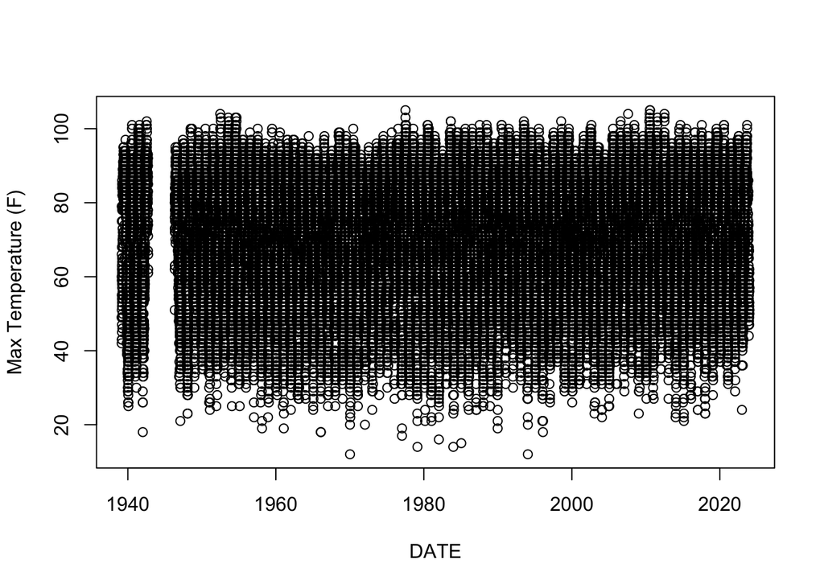

```r
# are there any data gaps? how many are there? You can graph the data to see if there are any holes
plot(x = rva$DATE,
     y = rva$TMAX,
     xlab = "DATE",
     ylab = "Max Temperature (F)")# as you can see in the graph, there is a gap. you are going to want to set your baseline to avoid those gaps
```

Provided we have a runway, we can then create a baseline of the first twenty-five years using `%>% filter()`.

```r
# Name your data.frame wisely! pipe operator (ctr + shift + m)
rva_base <-rva %>% # making a new fata fram from rva
  filter(YEAR <=1964) #1964 is 25 years ahead
# See if it worked!
summary(rva_base)
```

```
##         STATION                                        NAME
##  USW00013740:9346   RICHMOND INTERNATIONAL AIRPORT, VA US:9346
##
##
##
##
##
##
##       DATE                 PRCP             TMAX             TMIN
##  Min.   :1939-03-01   Min.   :0.0000   Min.   : 18.00   Min.   :-12.00
##  1st Qu.:1945-07-25   1st Qu.:0.0000   1st Qu.: 56.00   1st Qu.: 33.00
##  Median :1952-03-16   Median :0.0000   Median : 72.00   Median : 48.00
##  Mean   :1952-02-20   Mean   :0.1208   Mean   : 69.27   Mean   : 47.17
##  3rd Qu.:1958-08-08   3rd Qu.:0.0400   3rd Qu.: 84.00   3rd Qu.: 62.00
##  Max.   :1964-12-31   Max.   :8.7900   Max.   :104.00   Max.   : 78.00
##                       NA's   :1216     NA's   :1216     NA's   :1216
##       YEAR          MONTH
##  Min.   :1939   Min.   : 1.000
##  1st Qu.:1945   1st Qu.: 4.000
##  Median :1952   Median : 7.000
##  Mean   :1952   Mean   : 6.591
##  3rd Qu.:1958   3rd Qu.:10.000
##  Max.   :1964   Max.   :12.000
##
```

## 2: Establish temperature norms

What we consider as an abnormally hot or cold day depends on the time of year: we might consider a high of 72°F weirdly warm on January 1st, but surprisingly mild on August 1st. Thus, we will need to establish what is “normal” for a month during our baseline years.

We will make a new data.frame with only two columns: one for MONTH, the other for average maximum temperature during that month. We have to connect the command to group data by month value before we summarize mean maximum temperature.

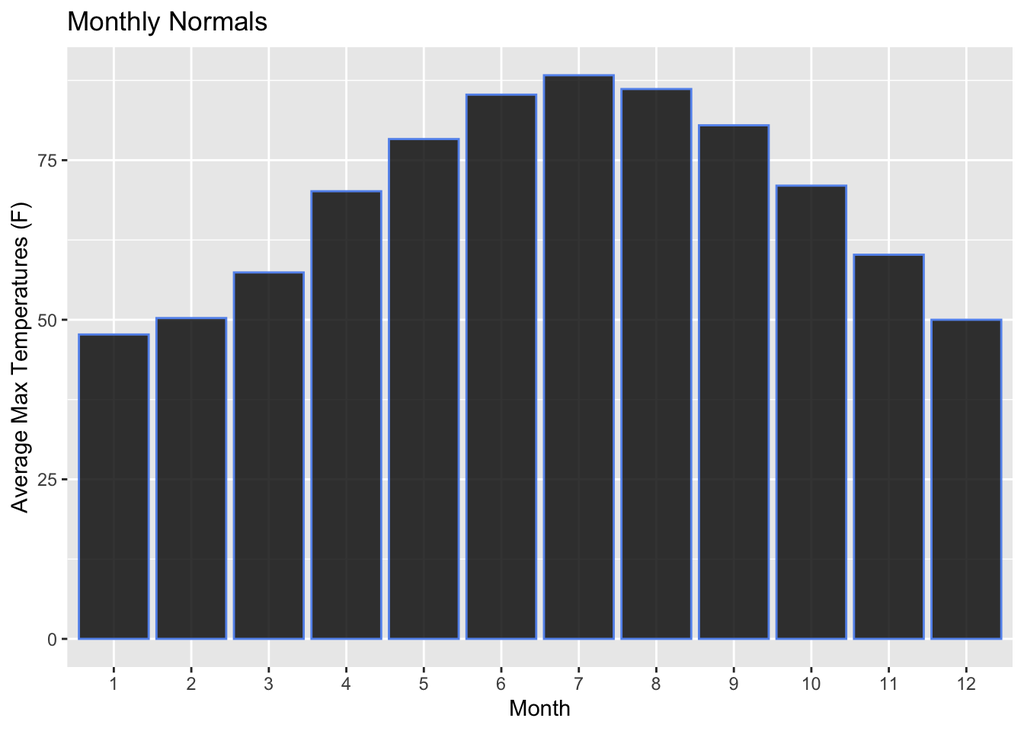

```r
# new data.frame for norms
rva_norm <- rva_base %>%
 group_by(MONTH) %>% #want the average for each month
  summarise(AVG_TMAX = #new column
              mean(TMAX, na.rm = T)) #average of TMAX

# Check out the data.frame to see if it worked.
ggplot(rva_norm,
       aes(x = as.factor( MONTH), #treat the numbered months as a factor
           y = AVG_TMAX))+
  geom_col(alpha = 0.8,
           fill = "black",
           color = "cornflowerblue")+
  labs(x = "Month",
       y = "Average Max Temperatures (F)",
       title = "Monthly Normals")
```

```r
# Plot the data.frame to see if the VALUES make sense
```

If the values look reasonable, we are on track to proceed to step 3!

## 3: Combine and subtract!

There are several ways to join different data.frames in dplyr. Because we want all records preserved, we will be using the `full_join()` function (instead of `left_join()` or `right_join()`, which we may use another day). In all of these functions, we have to specify three arguments:

For a join to work, we need to tell what column or columns the data.frames have in common, so it can align the rows properly. We do this with the argument `by =`; in this case, the two data.frames have `MONTH` in common.

```r
# create a new daily data.frame
rva_full <- full_join(rva,rva_norm,
                      by = "MONTH")
# did it work?# did it work?
summary(rva_full)
```

```
##         STATION                                         NAME
##  USW00013740:30895   RICHMOND INTERNATIONAL AIRPORT, VA US:30895
##
##
##
##
##
##
##       DATE                 PRCP            TMAX             TMIN
##  Min.   :1939-03-01   Min.   :0.000   Min.   : 12.00   Min.   :-12.00
##  1st Qu.:1960-07-23   1st Qu.:0.000   1st Qu.: 56.00   1st Qu.: 34.00
##  Median :1981-09-15   Median :0.000   Median : 72.00   Median : 48.00
##  Mean   :1981-09-07   Mean   :0.121   Mean   : 69.46   Mean   : 47.85
##  3rd Qu.:2002-11-07   3rd Qu.:0.040   3rd Qu.: 84.00   3rd Qu.: 63.00
##  Max.   :2023-12-31   Max.   :8.790   Max.   :105.00   Max.   : 81.00
##                       NA's   :1216    NA's   :1216     NA's   :1216
##       YEAR          MONTH           AVG_TMAX
##  Min.   :1939   Min.   : 1.000   Min.   :47.69
##  1st Qu.:1960   1st Qu.: 4.000   1st Qu.:57.41
##  Median :1981   Median : 7.000   Median :71.01
##  Mean   :1981   Mean   : 6.544   Mean   :68.92
##  3rd Qu.:2002   3rd Qu.:10.000   3rd Qu.:85.27
##  Max.   :2023   Max.   :12.000   Max.   :88.30
##
```

Now we can do this simple arithmetic of anomalies: creating a column that show how much warmer or cooler a day was than the historic monthly norm.

ANOMALY = TMAX - AVG_TMAX

```r
# Create anomaly column
rva_full$ANOMALY <- rva_full$TMAX - rva_full$AVG_TMAX
# Did it work?
summary(rva_full$ANOMALY)
```

```
##     Min.  1st Qu.   Median     Mean  3rd Qu.     Max.     NA's
## -36.4091  -5.9971   0.6957   0.4992   6.7333  33.5909     1216
```

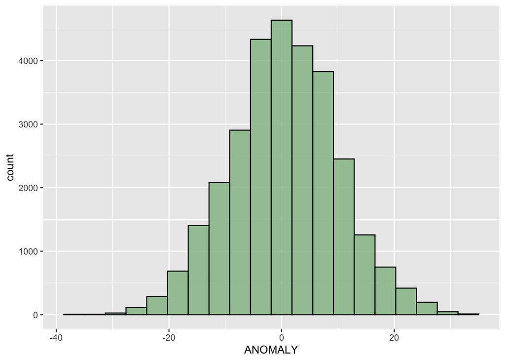

```r
# Check the distribution of values graphically
ggplot(rva_full,
       aes(x = ANOMALY))+
  geom_histogram(bins = 20,
                 color = "black",
                 fill = "darkseagreen",
                 alpha = 0.8)
```

## 4: Plot & trend assessment

Fantastic work! We now have daily temperature anomalies, which can may help us understand climate change in RVA.

Unfortunately, the *daily* data may not be the best scale on which to make these assessments – after all, putting 27,000+ observations on a graph makes for a messy visualization.

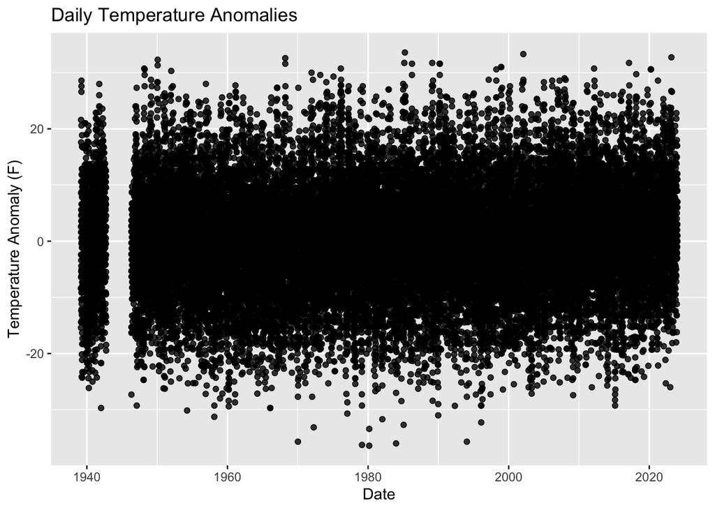

```r
# daily climate anomaly plot
ggplot(rva_full,
       aes(x = DATE,
           y = ANOMALY))+
  geom_point(alpha = 0.8)+
  labs(x = "Date",
       y = "Temperature Anomaly (F)",
       title = "Daily Temperature Anomalies" )
```

We need to complete one last wrangling to visualize the average anomaly by year. We can do this *because* our anomalies are on the same monthly scale. What command from `dplyr` should we use to average yearly anomalies?

```r
# Create simple data of year and climate variables
rva_yearly <- rva_full %>%
  drop_na(ANOMALY) %>% #gets rid of NA's, check rva_yearly in environment
  group_by(YEAR) %>% #create column one
  summarise(AVG_ANOM = mean(ANOMALY, #make column 2, name it, avg daily anomaly temps/year
                            na.rm = T),
            TOT_PRCP = sum(PRCP,
                           na.rn = T))
```

Finally, we have yearly data to plot! To make this visualization as effective as possible, we will want to:

1. Determine whether points or columns are more clearly demonstrate change (or the lack thereof).
2. Provide detailed, well-formatted labels, so the lay person will know what the graph is showing.
3. Reinforce variation in the height / y variable of our graph with color or fill.

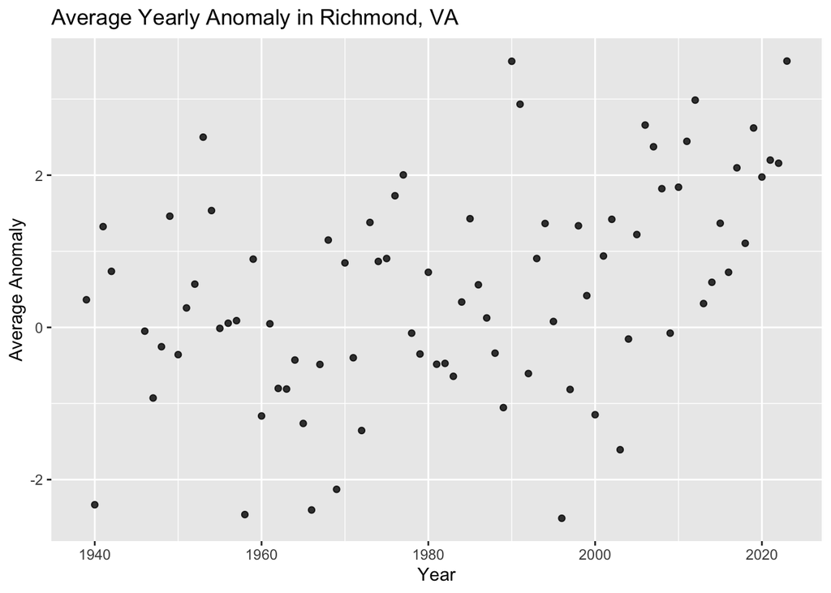

```r
# Point version
ggplot(rva_yearly,
       aes(x = YEAR,
           y = AVG_ANOM))+
  geom_point(alpha = 0.8)+
  labs (x = "Year",
        y = "Average Anomaly",
        title = "Average Yearly Anomaly in Richmond, VA" )
```

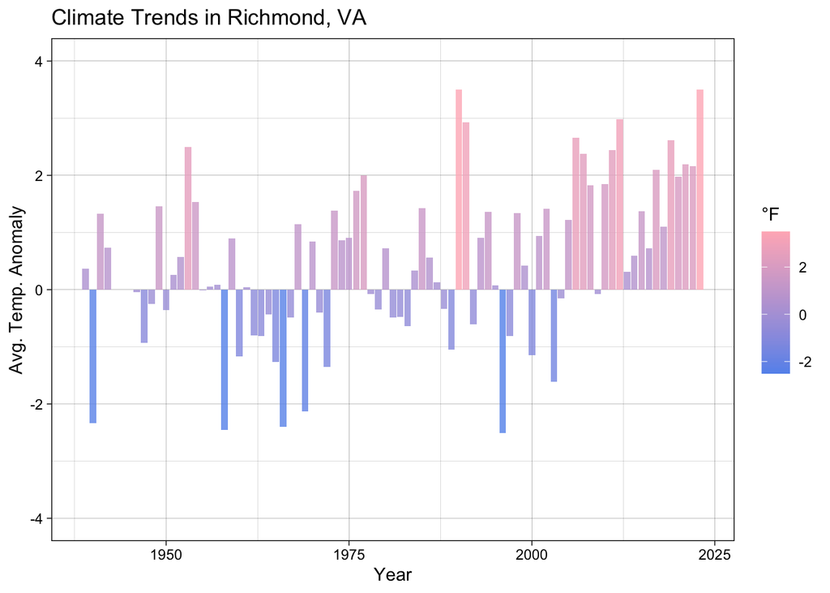

```r
# Column version
ggplot(rva_yearly,
       aes(x = YEAR,
           y = AVG_ANOM,
           fill = AVG_ANOM))+
  geom_col(alpha = 0.8)+
  labs(x = "Year",
       y = "Avg. Temp. Anomaly",
       title = "Climate Trends in Richmond, VA",
       fill = "°F")+
  scale_fill_gradient(low = "cornflowerblue",
                      high = "lightpink")+
   theme_linedraw()+
  ylim(-4,4)
```

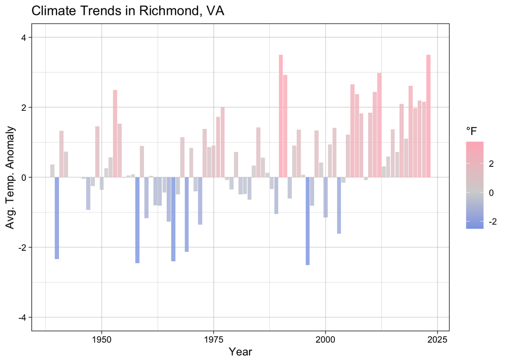

```r
ggplot(rva_yearly,
       aes(x = YEAR,
           y = AVG_ANOM,
           fill = AVG_ANOM))+
  geom_col(alpha = 0.8)+
  labs(x = "Year",
       y = "Avg. Temp. Anomaly",
       title = "Climate Trends in Richmond, VA",
       fill = "°F")+
  scale_fill_gradient2(low = "cornflowerblue",
                      mid = "lightgrey",
                      high = "lightpink")+
   theme_linedraw()+
  ylim(-4,4)
```

Based on what we see in our graph, is there evidence of climate change in Richmond? Is it warming or cooling? Are warm and cool years of equal magnitude, or do we see greater extremes in one versus the other?